# Practical Machine Learning Course Project Report

Patrick Cher

Aug 16, 2015

### Load Libraries

- Load libraries required for analysis
- Utilise 4 cores to reduce time required to generate analysis
- Set working directory

```r
# load libraries
library(ggplot2)
library(caret)
library(randomForest)
library(doMC)
# for better performance, use 4 cores
registerDoMC(cores=4)

# set working directory
setwd("/Users/patrickcher/Dropbox/Learning/Data Science/JHU Data Science/08 Practical Machine Learning/Course Project/Practical Machine Learning")
```

### Load Data

```r
# load data from both training and testing set
# replace #DIV/0! values with NA
trainingData <- read.csv("pml-training.csv", row.names = 1, na.strings = c("#DIV/0!"))
testingData <- read.csv("pml-testing.csv", row.names = 1, na.strings = c("#DIV/0!"))

# remove near zero covariates
nearZeroCovar <- nearZeroVar(trainingData, saveMetrics = T)
trainingData <- trainingData[, !nearZeroCovar$nzv]

# remove variables with more than 80% missing values
naValues <- sapply(colnames(trainingData),
                   function(x)
                     if(sum(is.na(trainingData[, x])) > 0.8 * nrow(trainingData)) {
                       return(T)
                     }
                   else{
                     return(F)
                   }
              )

trainingData <- trainingData[, !naValues]

# calculate correlations
correlations <- abs(sapply(colnames(trainingData[, -ncol(trainingData)]),
                           function(x)
                             cor(as.numeric(trainingData[, x]),
                                 as.numeric(trainingData$classe),
                                 method="spearman")
                          )
                    )
```

- From the plot below, there isn’t any strong predictors that correlate with classe well.

```r
summary(correlations)
```

```
##     Min.  1st Qu.   Median     Mean  3rd Qu.     Max.
## 0.001525 0.014720 0.052370 0.086210 0.137400 0.317300
```

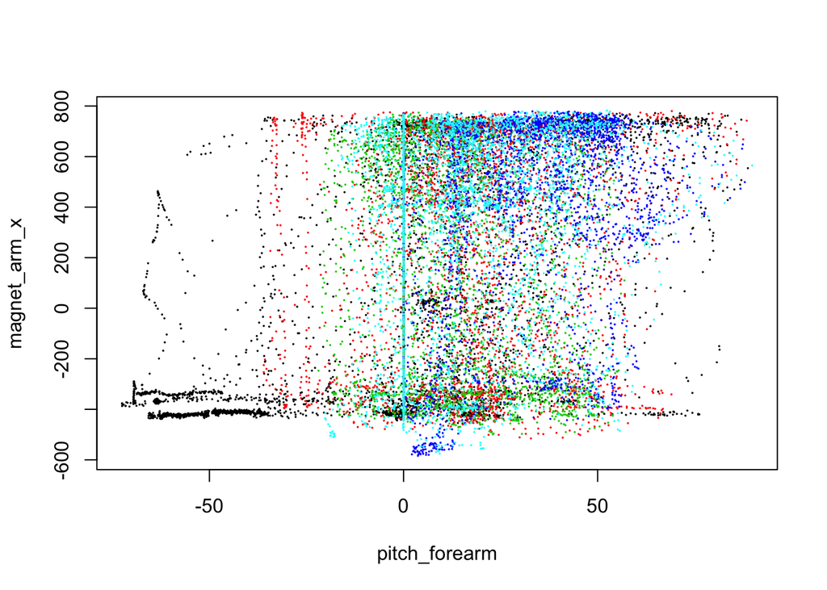

```r
# plot predictors
plot(trainingData[, names(which.max(correlations))],
     trainingData[, names(which.max(correlations[-which.max(correlations)]))],
     col = trainingData$classe, pch = 19, cex = 0.1,
     xlab = names(which.max(correlations)),
     ylab = names(which.max(correlations[-which.max(correlations)])))
```

* We will explore using boosting and random forest algorithm to generate more robust predictions.

### Boosting Model

- We will start by fitting the model with boosting algorithm and perfomr 10-fold cross validation to predict the classe

```r
set.seed(888)

# fitting model with boosting algorithm and 10-fold cross validation to predict classe
boostFit <- train(classe ~ ., method="gbm", data = trainingData,
                  verbose = F, trControl = trainControl(method = "cv", number = 10))
boostFit
```

```
## Stochastic Gradient Boosting
##
## 19622 samples
##    57 predictor
##     5 classes: 'A', 'B', 'C', 'D', 'E'
##
## No pre-processing
## Resampling: Cross-Validated (10 fold)
## Summary of sample sizes: 17660, 17659, 17659, 17662, 17659, 17659, ...
## Resampling results across tuning parameters:
##
##   interaction.depth  n.trees  Accuracy   Kappa      Accuracy SD
##   1                   50      0.8373286  0.7935807  0.010334952
##   1                  100      0.8994515  0.8726708  0.007652001
##   1                  150      0.9275828  0.9082575  0.007193720
##   2                   50      0.9574976  0.9461904  0.004975395
##   2                  100      0.9875648  0.9842706  0.002269365
##   2                  150      0.9922029  0.9901375  0.002065927
##   3                   50      0.9851696  0.9812405  0.002765139
##   3                  100      0.9937826  0.9921359  0.001589022
##   3                  150      0.9970440  0.9962612  0.001266954
##   Kappa SD
##   0.013085284
##   0.009699289
##   0.009118099
##   0.006305052
##   0.002871303
##   0.002613360
##   0.003500079
##   0.002009875
##   0.001602466
##
## Tuning parameter 'shrinkage' was held constant at a value of 0.1
##
## Tuning parameter 'n.minobsinnode' was held constant at a value of 10
## Accuracy was used to select the optimal model using  the largest value.
## The final values used for the model were n.trees = 150,
##  interaction.depth = 3, shrinkage = 0.1 and n.minobsinnode = 10.
```

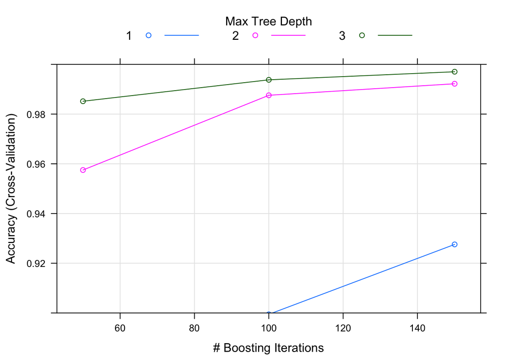

```r
# plot accuracy of the model on the scale of 0.9 and 1
plot(boostFit, ylim = c(0.9, 1))
```

- The boosting algorithm produced a good model with up to 0.997 accuracy.
- We will now try fitting the modeling with random forest algorithm to determine which algorithm produces better accuracy.

### Random Forests Model

- We will fit the model with random forest algorithm and similarly perform 10-fold cross validation to predict classe with other predictors.
- We will keep the 10-fold cross validation so that comparison can be done against the boosting model.

```r
# Fit model with random forests algorithm and 10-fold cross validation
# to predict classe with all other predictors.
set.seed(888)
rfFit <- train(classe ~ ., method = "rf", data = trainingData,
               importance = T, trControl = trainControl(method = "cv", number = 10))
```

```r
rfFit
```

```
## Random Forest
##
## 19622 samples
##    57 predictor
##     5 classes: 'A', 'B', 'C', 'D', 'E'
##
## No pre-processing
## Resampling: Cross-Validated (10 fold)
## Summary of sample sizes: 17660, 17659, 17659, 17662, 17659, 17659, ...
## Resampling results across tuning parameters:
##
##   mtry  Accuracy   Kappa      Accuracy SD   Kappa SD
##    2    0.9926613  0.9907161  0.0017849269  0.0022581763
##   40    0.9993885  0.9992265  0.0007895731  0.0009987299
##   79    0.9991335  0.9989039  0.0007987582  0.0010103493
##
## Accuracy was used to select the optimal model using  the largest value.
## The final value used for the model was mtry = 40.
```

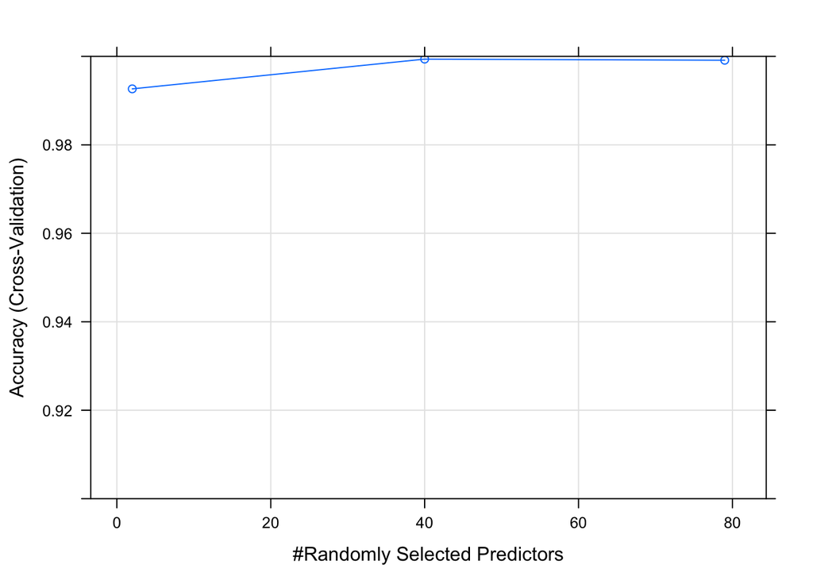

```r
# Plot accuracy of the model on the same scale as boosting model for comparison.
plot(rfFit, ylim = c(0.9, 1))
```

```r
impt <- varImp(rfFit)$importance
impt$max <- apply(impt, 1, max)
impt <- impt[order(impt$max, decreasing = T), ]
```

- From the plots, this model has better performance in accuracy.
- The random forests algorithm produced more accurate model with accuracy closer to 1.

### Final Model

- Comparing the results of boosting model and random forests model, random forests model has better accuracy. Hence it will be used for the final model.
- The estimated out of sample error rate for random forests model is 0.04%.
- The final model contains 500 trees with 40 variables tried at each split.

```r
# final model
rfFit$finalModel
```

```
##
## Call:
##  randomForest(x = x, y = y, mtry = param$mtry, importance = ..1)
##                Type of random forest: classification
##                      Number of trees: 500
## No. of variables tried at each split: 40
##
##         OOB estimate of  error rate: 0.04%
## Confusion matrix:
##      A    B    C    D    E  class.error
## A 5580    0    0    0    0 0.0000000000
## B    1 3795    1    0    0 0.0005267316
## C    0    3 3419    0    0 0.0008766803
## D    0    0    1 3214    1 0.0006218905
## E    0    0    0    1 3606 0.0002772387
```

```r
# prediction
(prediction <- as.character(predict(rfFit, testingData)))
```

```
##  [1] "B" "A" "B" "A" "A" "E" "D" "B" "A" "A" "B" "C" "B" "A" "E" "E" "A"
## [18] "B" "B" "B"
```

```r
# write prediction files
pml_write_files = function(x){
  n = length(x)
  for(i in 1:n){
    filename = paste0("./prediction/problem_id_", i, ".txt")
    write.table(x[i], file = filename, quote = FALSE, row.names = FALSE, col.names = FALSE)
  }
}

pml_write_files(prediction)
```